# The expected value of a stochastic trajectory in a hazardous landscape

K Erik J Olofsson

August 19, 2018

```r
# Reproduce this document as follows.
rmarkdown::render('random-hazardous-value.Rmd')
```

# Problem statement

We are interested in finding the expected value $u(x,t)$ of an integral of a finite-time trajectory $X(\tau)$ of a stochastic differential equation (SDE) conditioned on knowledge of the initial (current) state $X(t)=x$ (one-dimensional). The path-integral is defined in terms of the functions $h(x,t)\geq 0$, $f(x,t)$, and $\psi(x)$. The SDE is defined in terms of the functions $\mu(x,t)$ and $\sigma(x,t)$. Specifically we want to evaluate

$$u(x,t) \equiv \mathrm{E}\left[ C_{path} + C_{terminal} \Bigg\rvert X(t) = x \right]$$

where

$$C_{path} = \int_{r=t}^{T}e^{-\int_{\tau=t}^{r}h(X,\tau)d\tau}\times f(X,r) dr$$

and

$$C_{terminal} = e^{-\int_{\tau=t}^{T}h(X,\tau)d\tau}\times\psi(X(T))$$

subject to the drift-diffusion dynamics

$$dX = \mu(X,t)dt + \sigma(X,t)dW$$

where $W$ is a Wiener process. If the function $f$, $\psi$, $h$, $\mu$, and $\sigma$ are not explicitly depending on the absolute time $t$ ($f(x,t)=f(x)$ and so on), then we may call the problem time-homogeneous. We call the general problem statement time-inhomogeneous. In what follows we stick with the general time-inhomogeneous problem.

## Probability of path survival

Let $f=0$ and $\psi=1$. Then
$$u(x,t) = \mathrm{E}\left[ e^{-\int_{\tau=t}^{T}h(X,\tau)d\tau} \Bigg\rvert X(t) = x \right]$$
which is recognized as a (conditional) survival probability (the fraction of times we collect the terminal reward of one unit). We might call $h$ the hazard function, linking it to survival analysis. Further suppose $h(x,t)=\lambda$. Then the above value reduces to $u(x,t) = e^{-\lambda(T-t)}$, so that the survival probability is determined by an exponential distribution evaluated at the time-to-go point $T-t$, independent of the location $X(t)=x$. In the case that $h=0$ everywhere, then $u(x,t)=1$. All paths survive with probability one.

## Example problem

For illustration, we will work with a specific numerical example defined as follows.

```r
# Drift-diffusion system
mu.xt <- function(x, t) { 0.5*(x - t/2)^2 }
sigma.xt <- function(x, t) { 0.1 + 0.9*t*(sin(pi*x))^2 }

# Value-generating functions
f.xt <- function(x, t) { cos(2*pi*t)/(1 + exp(-x^2/0.1)) }
h.xt <- function(x, t) { 0.5 * (1 + x^2)*t + 0.5*x^4 }
psi.x <- function(x) { 0.2 * sin(pi*x) }

# Package the definitions
sdep <- list(
  mu = mu.xt,
  sigma = sigma.xt,
  f = f.xt,
  h = h.xt,
  psi = psi.x)

# Domain (x=-L..L,t=0..T) and a trial point (x0,t0)
L <- 1.0
T <- 2.0
t0 <- 0.250
x0 <- -0.333
dt <- 2e-4  # Euler-Maruyama step

stopifnot(t0 >= 0 && t0 < T)
stopifnot(abs(x0) < L)

N <- 1000  # path realizations to use for value estimation (per approach)
P <- 10    # path realizations to visualize once
```

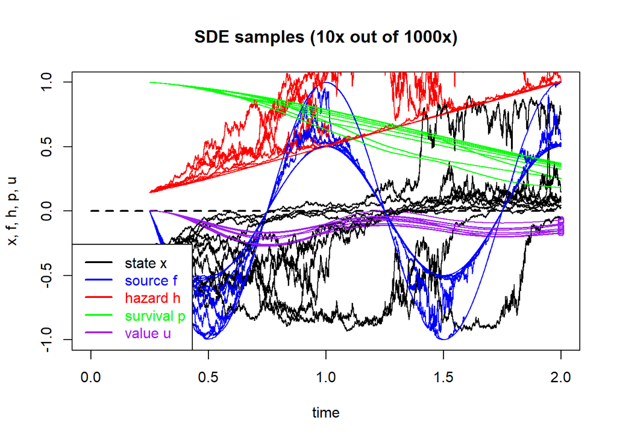

We note from the above graph that the expected value function $u(x,t)$ attempts to summarize quite a mess.

# Approaches

## Deterministic backward PDE

We can solve a Feynman-Kac PDE for $u(x,t)$ backward in time $t=T\ldots t_0$ using the terminal condition $u(x,T)=\psi(x)$. The inhomogeneous PDE is given as follows.

$$\partial_t u + \mu(x,t)\partial_x u + \frac{1}{2}\sigma^2(x,t)\partial^2_{xx}u - h(x,t)u + f(x,t) = 0$$

For simplicity we consider absorbing boundary conditions in space which means that $u(t,x=\pm L)=0$ for domain boundaries at $x=-L$ and $x=L$. This approach has the benefit that we get the value $u(x,t)$ for all $(x,t)$ (but the source terms $\psi$ and $f$ cannot be switched without requiring a resolve).

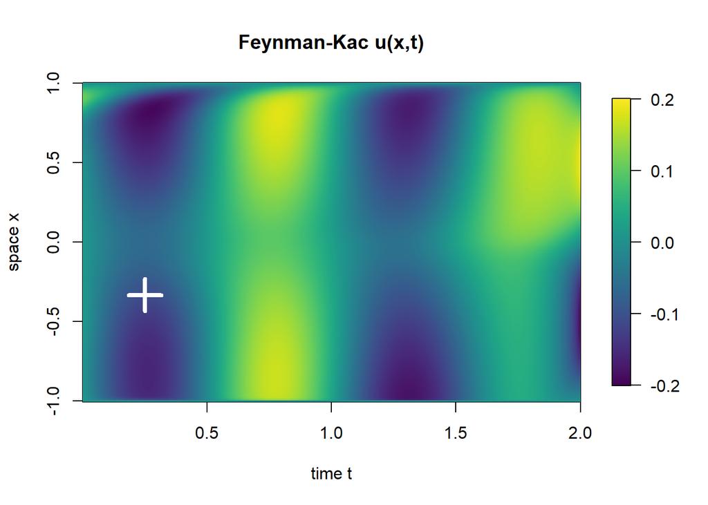

```
## [1] "backward PDE point value u(x=-0.333, t=0.250) = -0.107863"
```

## Deterministic forward PDE

Another option is to solve for the density function $p(x,t)$ for $t=t_0\ldots T$, which is governed by the Fokker-Planck PDE
$$\partial_t p = -\partial_x\left(\mu(x,t) p\right) + \frac{1}{2}\partial^2_{xx}\left(\sigma^2(x,t) p\right) - h(x,t) p$$
with the initial condition $p(x, t_0) = p_0(x)$. If $p_0(x) = \delta(x-x_0)$, then the point value $u$ can be obtained by the integral
$$u(x_0, t_0) = \int_{t_0}^{T} dt \int_{-L}^L dx f(x, t) p(x, t) + \int_{-L}^L dx \psi(x)p(x,T)$$
It may be awkward to have a delta function as initial density so we may attempt the approximation $p_0(x)=\exp\left(-(x-x_0)^2/(2\sigma_0^2)\right)/(\sqrt{2\pi}\sigma_0)$. This approach has the benefit that we can recycle the solution $p(x,t)$ for any number of value functions $\psi$, $f$. A drawback is that we get only a point value $u(x_0, t_0)$.

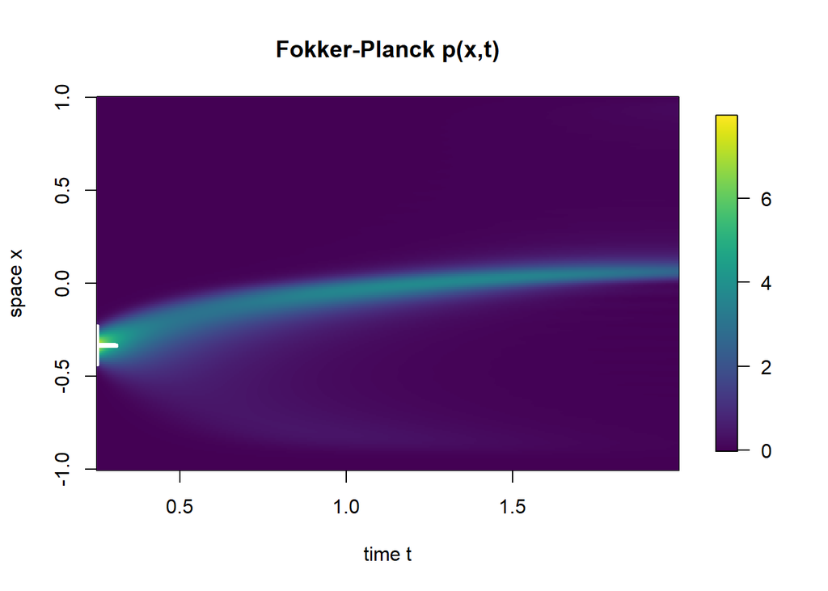

```
## [1] "forward PDE point value u(x=-0.333, t=0.250) = -0.107724"
```

## Pointwise forward simulations

We can pick a location $(x,t)$ and simulate the SDE forward $t\ldots T$ repeatedly and take the average of the path-integral as defined. This would give a point value estimate of $u(x,t)$. Another option is to kill each simulation at a local rate given by the hazard $h$. The average of the (possibly incomplete) path integrals of $f$ is the estimate of the value $u$ in this case (so only using $h$ to kill the path, not in the actual integration). Both methods should give the same result but in general the schemes have different variance properties and computational speed. A benefit is that this scales to high-dimensional problems. A drawback is that we only get random samples of point values $\widehat{u}(x, t)$ (see next subsection how this can be improved).

```r
sde.value.samples <- foreach(ii = 1:N, .combine = 'rbind',
    .multicombine = TRUE, .inorder = FALSE) %doop% {
  rii <- sim.sde.euler(sdep, t0, x0, T, L, dt, save.path = FALSE)
  rii.alt <- sim.sde.euler.kill(sdep, t0, x0, T, L, dt, save.path = FALSE)
  c(rii$utot, rii.alt$utot)
}
u.samples <- as.vector(sde.value.samples[, 1])
u.samples.alt <- as.vector(sde.value.samples[, 2])
```

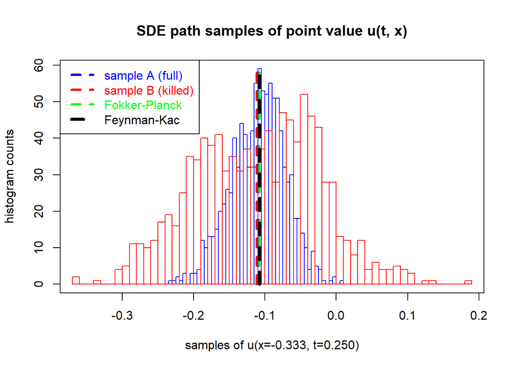

## Scattered forward simulations

The key idea here is that each observed path $(x,t)$ can be used as a sample for more than one point $u(x,t)$. Specifically, we get samples of $u$ also at times $\tau$, $t < \tau < T$. The aggregate path sample information may then cover a significant portion of the domain of interest. All we need to do is some book-keeping so that we count correctly. We illustrate this by “painting” the value surface using path realizations in two ways. The first always starts at the same initial point $(x_0, t_0)$. The second approach randomized the initial conditions uniformly over the domain. It is observed that starting at the same point gives a “search beam” forward for the value.

```r
xt.nx <- 100
xt.nt <- 400
xt.block <- 50
sde.xto.0 <- foreach(ii = 1:round(N/xt.block), .combine = 'merge.xt.cell',
  .multicombine = FALSE, .inorder = FALSE) %doop% {
  xto <- create.xt.cells(xt.nx, c(-L, L), xt.nt, c(0, T))
  for (jj in 1:xt.block) {
    rij <- sim.sde.euler(sdep, t0, x0, T, L, dt, save.path = TRUE)
    xto <- update.xt.cell(xto, rij)
  }
  xto
}
```

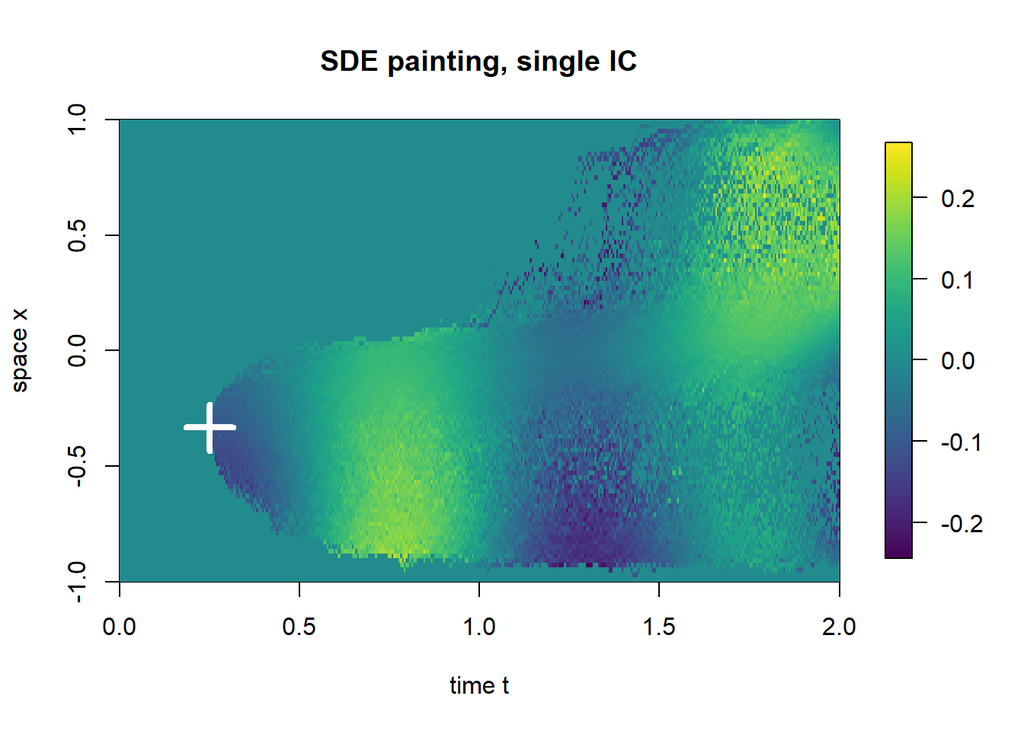

```r
sde.xto.1 <- foreach(ii = 1:round(N/xt.block), .combine = 'merge.xt.cell',
  .multicombine = FALSE, .inorder = FALSE) %doop% {
  xto <- create.xt.cells(xt.nx, c(-L, L), xt.nt, c(0, T))
  for (jj in 1:xt.block) {
    rij <- sim.sde.euler(sdep, runif(1)*(T - 10*dt), L*(2*runif(1) - 1), T, L, dt, save.path = TRUE)
    xto <- update.xt.cell(xto, rij)
  }
  xto
}
```

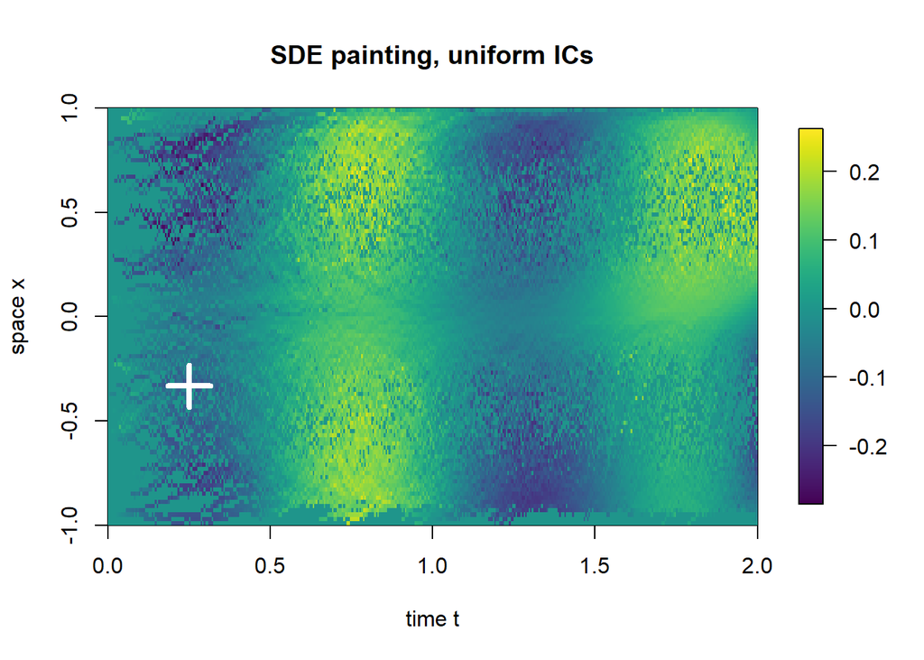

We can also paint the value function without access to the underlying hazard (as we did for the point value above). The resulting image has a bit more variance for the same number of path samples (here 1000) and looks like this (single initial condition $u(x_0,t_0)$).

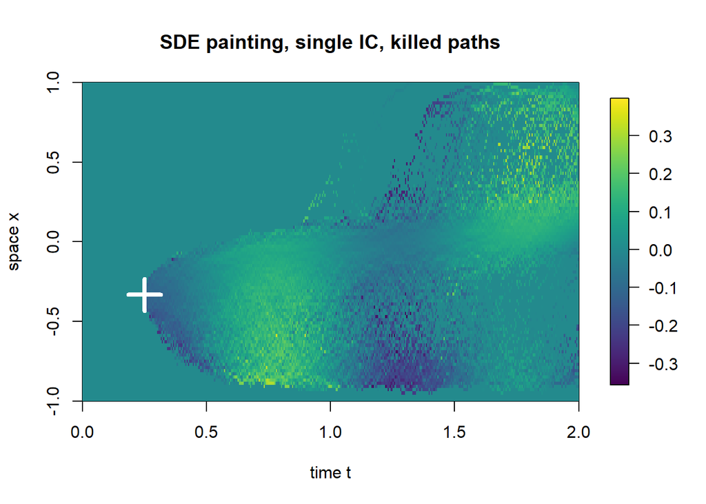

## Dynamic programming

It is “straightforward” to discretize the underlying SDE in space and time (this was also done, differently, behind the scenes above). If we partition the space into distinct cells, we end up with a typical discrete stochastic dynamic programming equation (i.e. Markov Process form) which is solved by backward induction.

$$u_{i}(k) = r_{i}(k) + \gamma_{i}(k) \sum_j p_{i, j}(k) u_{j}(k + 1)$$

Here $k$ is a discrete time index, $i$ is a space cell index, $r_i(k)$ is the local value accrued, $\gamma_i(k)$ is the probability of surviving the next transition, and $p_{i,j}(k) \geq 0$ is the transition probability for the jump $i\rightarrow j$. It generally holds $\sum_j p_{i,j}(k) \leq 1$ (probability mass can be consumed by e.g. an absorbing boundary). Term $r$ originates from source function $f$, $\gamma$ comes from hazard $h$, and the transition probabilities come from the drift and the diffusion $\mu$, $\sigma$.

```r
dynp.u <- solve.dynp.value(sdep, xt.nx, c(-L, L), xt.nt, c(0, T))
```

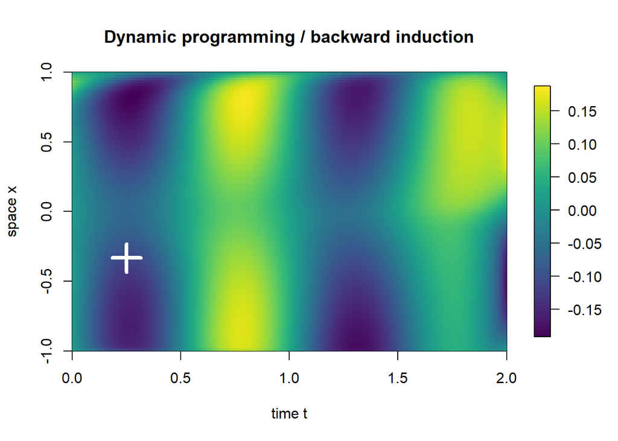

Note that we could also discretize the underlying SDE as a forward Markov Process, as specified by $p_{i,j}(k)$ and $\gamma_i(k)$, therefore producing a pure discrete-time approximation of the Fokker-Planck approach.

## Function approximations

The simulation based valuation methods above do not reference the underlying dynamical system equations. They are based on seeing a stream of sample values $x$, $t$, $f$, $\psi$, and perhaps $h$. The stream generator can be a black-box. In contrast, the “complete solution methods”; Feynman-Kac, Fokker-Planck plus space-time integral, Dynamic Programming however require the full problem specifications.

Suppose we observe the stream of samples $\left\{t,x\right\}$ over many paths, covering a significant portion of the state-space. If the time-step between observations is $\Delta$ we may consider each path increment $\mathrm{dx}$ ($x\rightarrow x+\mathrm{dx}$ as $t\rightarrow t+\Delta$) to be a sample from the normal distribution

$$\mathrm{dx}(x,t) \sim \mathcal{N}\left(\mu(x,t)\Delta, \sigma^2(x,t)\Delta\right)$$

This means we can back out $\widehat{\mu}$ and $\widehat{\sigma}$ given enough transition data $\left\{t,x,\mathrm{dx}\right\}$. One sneaky way to fit the drift-diffusion generating functions is to pose two distinct supervised learning problems. One, $f_1$ fits $\mathrm{dx}/\Delta$. The other, $f_2$, fits $\mathrm{dx}^2/\Delta$. It then follows $\widehat{\mu} = f_1$ and $\widehat{\sigma} = \left(f_2 - \Delta f_1^2\right)^{1/2}$. The source term can (in this case) be cast as a noise-free fitting problem $f_3 = \widehat{f}$. We can then proceed to solve the dynamic programming equation based on these estimated functions $\left\{f_1, f_2, f_3\right\}$. The below result used `xgboost` in the background (decision-tree based gradient boosting machine). As before, 1000 path samples were used.

```r
xt.nk <- 10 # decimation factor
xt.dat <- foreach(
  ii = 1:round(N / xt.block), .combine = 'rbind',
  .multicombine = FALSE, .inorder = FALSE) %doop%
{
  d <- NULL
  for (jj in 1:xt.block) {
    rij <- sim.sde.euler(sdep, runif(1) * (T - 10 * dt), L * (2 * runif(1) - 1), T, L, dt, save.path = TRUE)
    tij <- decimate.dx.data(rij, xt.nk)
    d <- rbind(d, tij)
  }
  d
}
```

Now use the table `xt.dat` which has 452048 rows (one per sample, decimated time-series data).

```
## [1] "fitted XGB model f1 ~ E[dx/delta] (34 rounds)"
```

```
## [1] "fitted XGB model f2 ~ E[dx^2/delta] (131 rounds)"
```

```
## [1] "fitted XGB model f3 ~ E[f] (500 rounds)"
```

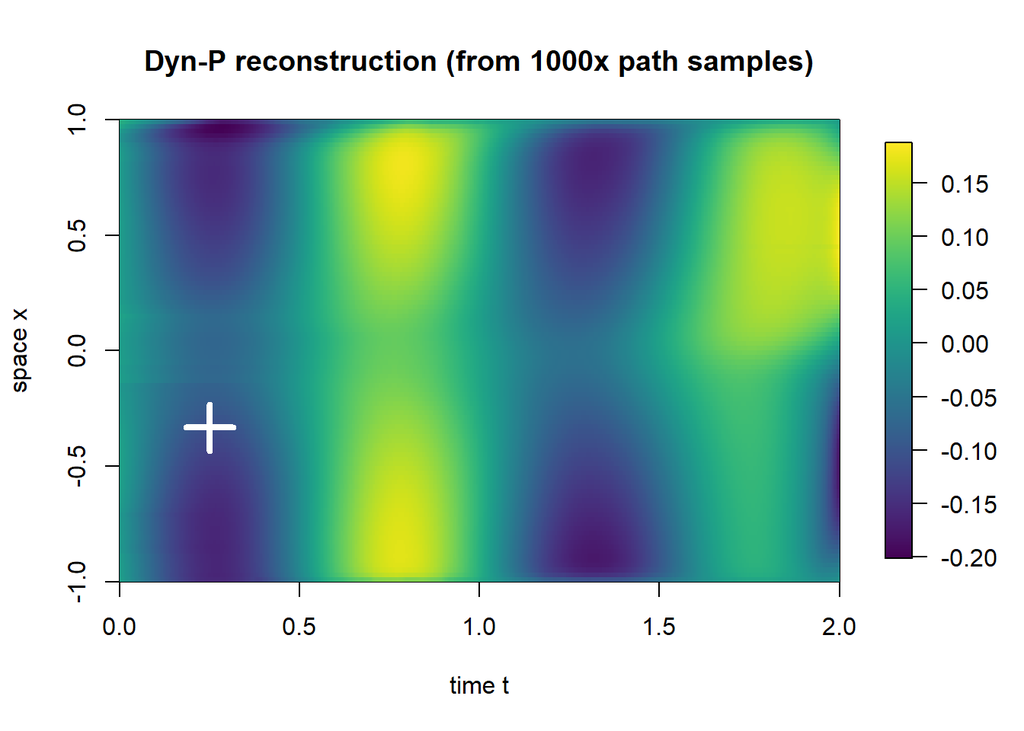

It is also possible to learn the hazard $h$ from the spatio-temporal killing rate. For simplicity, the true $h$ was used in the present illustration. The relative difference ($2$-norm) between the above plot and the corresponding full-information dynamic programming solution earlier is 0.131. The relative error in the drift estimate was 0.521. The relative error in the diffusion estimate was 0.155. And the relative error in the source function was 0.0345.

# Notes

Path value problems in higher dimensions are, in general, significantly more challenging.

This `rmarkdown` document was built with `R` version 3.4.3.